# 第7回 ABMシミュレーションで条件を一つずつ変えて試す

経済プログラミング特論II

第7回

ABMシミュレーションで  
条件を一つずつ変えて試す

何を見せるか・誰がいるか・ルールに無いもの

経済プログラミング特論II

第7回 — Topic01

情報条件

平均を見せると、協力は下がる

## 前の回と今回の地図

> この回のあなたは、実験を企画して、結果を読んで報告する人です。

前の回：罰のルール

同じ 100 人の社会で、罰を足して比べた  
罰なしの社会は  
9.2 から下がり、最後は 3.62

今回：ほかの条件を 1 つずつ

罰なしの社会を比べる相手にして  
条件を 1 つだけ変えて回す

| 変える条件 | 比べる値 | 10 ラウンドの平均拠出 | 動いたか |
| --- | --- | --- | --- |
| **1 平均を見せるか** | **見せる／見せない** | **？** | **？** |
| 2 ただ乗りの人数 | 10・30・50% | ？ | ？ |
| 3 いつも出す人数 | 0・10・20% | ？ | ？ |
| 4 倍率 | 1.6・2.4・3.2 | ？ | ？ |

## 今日の道のり

**今日のゴール**：人では試せない「もしも」を、ABM で 1 つずつ試し  
動く条件と、動かない条件に分けて報告する

1

平均を見せるか

演習 1 全体の平均を見せる

2

ただ乗りの人数

演習 2 ただ乗りを 20 人に

3

いつも出す人数

演習 3 いつも出す人を 5 人に

4

倍率

演習 4 倍率を 2.0 に

いまココ。**平均を見せるかどうか**だけを変えて、協力の線を比べる

## このトピックで学ぶこと

2026年度のデータ

- **ここまで**：前の回の罰なしの社会は、ラウンドを追うごとに下がった  
  実験の日も、平均 8.80 を見せた後の 2 回目は 7.19 に下がった
- **でも**：「平均を見せなかったら」は、もう教室ではやり直せない
- **問い**：分析する人として、平均を見せるか見せないかだけを変えて  
  協力の線がどう変わるかを比べる
- **言えること**：終わると、平均を見せた後に下がったことを  
  条件の言葉で報告できる
- **進め方**：4 人の班の表 → 100 人の 2 本の線 → 教室の数

そこで、前の回の社会の **1 行だけ**を変えて  
平均を見せない社会を作る

## 平均を見せない社会の平均拠出

社会の中で平均を使うのは、予想を「他の 3 人の平均」にする 1 行だけ  
そこを「最初の 15 のまま」にして 10 ラウンド続けると、平均拠出は

- **①** 上がる
- **②** 変わらない
- **③** 下がる

動画を止めて、①〜③から 1 つ選んで、少し考えてから再生

## 4 人の班の 2 つの社会

まず、前の回と同じ 4 人で、手で追う（同じ 4 人で 3 ラウンド）

[figure not shown]

見せるB の 2 回目の予想：(0 ＋ 12 ＋ 20) ÷ 3 ＝ 10.67 → × 0.8 ＝ 8.53

見せないB の予想は 15 のまま → 0.8 × 15 ＝ 12 のまま

## 情報条件

**他の人の情報をどこまで知らせるか**

定義

**情報条件**意思決定の前に、他の参加者の選択について  
どの情報を知らせるかを定めた実験条件

このモデルでは、予想に使う数で決まる  
（見せる社会は他の 3 人の平均・見せない社会は最初の 15）

- **例**：前回の平均点をみんなに知らせる
- **動き方**：合わせる人は、周りの数を知って初めて下げる  
  知らなければ、最初の予想のまま

## 100 人の 2 つの社会

今度は 100 人で、毎ラウンド 4 人組を組み直して 10 ラウンド

[figure not shown]

10 ラウンドの平均：見せる 4.89 ／ 見せない 9.20（入口の答えは ②）

seed（100 人の並べ方と組み方）を 10 通り変えても、10 本とも見せないほうが上

## デモ 条件の実験室：情報

決め方

合わせる人が出す点 ＝ 予想 × 0.8。見せない社会では、予想は最初の 15 のまま

- **何を見るか**：前の回の罰なしの社会（灰色）と、条件を 1 つだけ変えた社会を比べる。  
  どちらも 100 人・10 ラウンド・同じ seed 42。
- **図の意味**：横軸＝ラウンド・縦軸＝平均拠出（0〜20）。  
  灰色の太線＝基準、色の線＝押した条件
- **操作**：「見せない」を押すと線が重なる。「消す」で基準だけに戻る

ミッション 「見せない」を押すと、線はどう動くか

※ 次のスライドへ進むときは、デモの枠の外を一度クリックしてから ← → キーを押す

[interactive chart not shown]

## 教室の数との照らし合わせ

2026年度のデータ

[figure not shown]

- **向き**：モデルは見せると 9.20 → 6.75 と下がり、見せないと変わらない  
  教室も 8.80（49 人）→ 7.19（48 人）と下がった
- **分けられない**：教室には見せなかった組が無い  
  下がったのが見せたからか、2 回目だからかは分からない

合うのは向きまで

## Q&A

2026年度のデータ

Q1 見せないほうが協力が続くなら、見せないのが正解？

9.20 は「予想を変えない」と**書いた**結果  
現実で隠しても、人が最初の予想を信じ続けるとは限らない

Q2 0.8 × 8.80 ＝ 7.04 は教室の 7.19 に近い。モデルは正しい？

近いのは **1 か所の数**だけ。差 0.15 は、たまたまでも出る  
確かめられたのは、下がる向きまで

モデルの数は、書いたルールの結果として読む

## 演習1 見せる平均の変更

演習 1

全体の平均を見せると、平均拠出は 4.89 と比べてどうなるか

```python
rec = society(info="none")             # ← ここを書き換える
print("拠出:", mean_of(rec, "contribution"),
      " 受け取り:", mean_of(rec, "gross"))
```

info＝何を知らせるか：`"group"` 班の 3 人の平均（見せる社会）・`"none"` 知らせない・`"all"` 全体の平均

1. **実行する**：ノート段 1 の準備のセルを ▶ してから、提出のセルを ▶  
   （いまは見せない社会なので、拠出は 9.2）
2. **予想する**：1 行目を `rec = society(info="all")` に書き換えると  
   平均拠出は、見せる社会の 4.89 と比べて（上がる／ほぼ同じ／下がる）
3. **終わり**：実行して出た 2 つの数と、一文を答え欄に書く

⏸ PAUSE 動画を止めて $5$ 分。1 行が出たら再生に戻る

## まとめ

演習 1 の答え `rec = society(info="all")`  
拠出: 4.87 受け取り: 22.92

| 変える条件 | 比べる値 | 10 ラウンドの平均拠出 | 動いたか |
| --- | --- | --- | --- |
| **1 平均を見せるか** | **見せる／見せない** | **4.89 → 9.20** | **動く（↑）** |
| 2 ただ乗りの人数 | 10・30・50% | ？ | ？ |
| 3 いつも出す人数 | 0・10・20% | ？ | ？ |
| 4 倍率 | 1.6・2.4・3.2 | ？ | ？ |

分析する人として言えること：平均を見せると協力は下がり  
見せないと最初のまま続く。どの平均を見せるかは、ほとんど効かない  
まだ言えないこと：社会に誰が混ざっているかで、協力はどこまで変わるか  
これを次のトピックで見る

経済プログラミング特論II

第7回 — Topic02

型の構成

ただ乗りの人が増えると、どこまで下がるか

## 今日の道のり

**今日のゴール**：人では試せない「もしも」を、ABM で 1 つずつ試し  
動く条件と、動かない条件に分けて報告する

1

平均を見せるか

演習 1 全体の平均を見せる

2

ただ乗りの人数

演習 2 ただ乗りを 20 人に

3

いつも出す人数

演習 3 いつも出す人を 5 人に

4

倍率

演習 4 倍率を 2.0 に

いまココ。**ただ乗りの人数**だけを変えて、協力がどこまで下がるかを見る

## このトピックで学ぶこと

2026年度のデータ

| 変える条件 | 比べる値 | 10 ラウンドの平均拠出 | 動いたか |
| --- | --- | --- | --- |
| 1 平均を見せるか | 見せる／見せない | 4.89 → 9.20 | 動く（↑） |
| **2 ただ乗りの人数** | **10・30・50%** | **？** | **？** |
| 3 いつも出す人数 | 0・10・20% | ？ | ？ |
| 4 倍率 | 1.6・2.4・3.2 | ？ | ？ |

- **ここまで**：平均を見せるかどうかで、線が 4.89 と 9.20 に分かれた
- **でも**：ただ乗り型 30 人は、モデルを作る人が置いた数  
  実験の日の 1 回目に 0 点だった人は、49 人中 8 人（16%）
- **問い**：分析する人として、ただ乗り型の人数だけを変えて  
  協力がどこまで下がるかを確かめる
- **言えること**：終わると、報告の数に「どんな人が何人の社会か」を  
  添える理由を、数で言える
- **進め方**：4 人の班の 3 つの表 → 100 人の 3 本の線 → 合わせる人の棒

## ただ乗りを増やした社会の平均拠出

100 人のまま、ただ乗り型を 30 人から 50 人に増やす  
（増えた 20 人ぶん、合わせる人を 60 人から 40 人に減らす）  
ほかは同じで 10 ラウンド続けると、平均拠出は 4.89 と比べて

- **①** ほぼ同じ
- **②** 少し下がる
- **③** 半分くらいまで下がる

動画を止めて、①〜③から 1 つ選んで、少し考えてから再生

## 4 人の班の 3 つの社会

まず、前の回と同じ 4 人で、席の型を 1 つずつ替えて手で追う（同じ 4 人で 3 ラウンド）

[figure not shown]

2 人C の 2 回目の予想：(0 ＋ 0 ＋ 20) ÷ 3 ＝ 6.67 → × 0.8 ＝ 5.33 で止まる

B の分だけ？B の分だけ下がるなら 8.80 − 7.61 ÷ 4 ＝ 6.90 のはず  
実際は 6.33（C も 5.33 に下げた）

## 型の構成

**社会にどんな人が何人いるか決めること**

定義

**型の構成**集団に含まれる行動の型ごとの人数を  
定めた、モデルの設定

このモデルでは、作る人が決める  
（前の回からの社会は、ただ乗り型 30・条件付き協力型 60・無条件協力型 10）

- **例**：100 人のうち、いつも 0 の人を 30 人、合わせる人を 60 人  
  いつも 20 の人を 10 人と決める
- **動き方**：同じルールの社会でも、どの型の人が何人いるかで  
  協力が下がっていく先が違う

## 100 人の 3 つの社会

今度は 100 人で、ただ乗り型を 10・30・50 人に（毎ラウンド 4 人組を組み直して 10 ラウンド）

[figure not shown]

10 ラウンドの平均：10% 7.12 ／ 30% 4.89 ／ 50% 3.47  
（入口の答えは ②・約 7 割）

seed（100 人の並べ方と組み方）を 10 通り変えても、10 本とも 10% は基準より上・50% は下

## デモ 条件の実験室：ただ乗り

決め方

合わせる人が出す点 ＝ 予想 × 0.8  
（予想＝前のラウンドの、班の他の 3 人の平均）

- **何を見るか**：ただ乗りの人の割合だけを 10%・30%（基準）・50% にした社会。  
  減った・増えた分は合わせる人で埋める。
- **図の意味**：横軸＝ラウンド・縦軸＝平均拠出（0〜20）。  
  灰色の太線＝基準、色の線＝押した条件
- **操作**：右で条件を選び、ボタンを押すと線が重なる。「消す」で基準だけに戻る

ミッション 3 本の線の、10 ラウンド目の高さを読む

※ 次のスライドへ進むときは、デモの枠の外を一度クリックしてから ← → キーを押す

[interactive chart not shown]

## 合わせる人の 10 ラウンド目の拠出

ただ乗りが増えると、合わせる人（条件付き協力型）の拠出はどうなるか

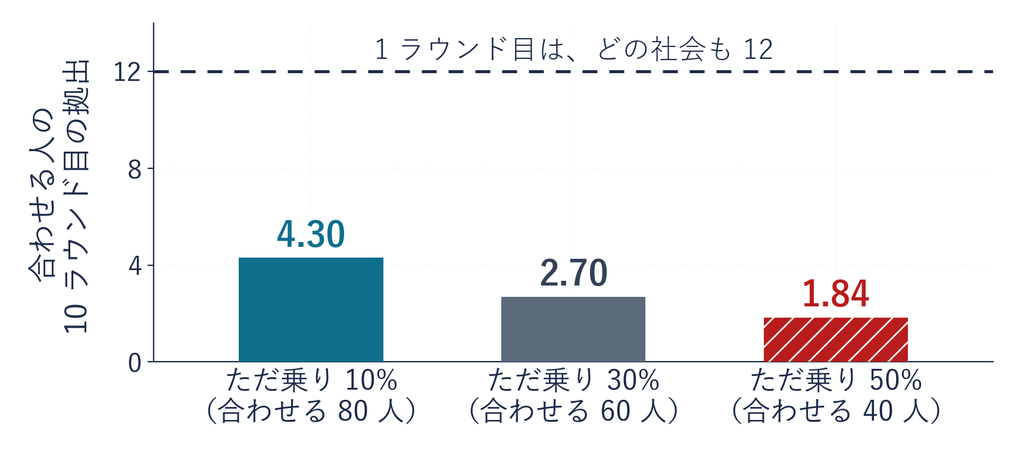

払わない人が増えると、合わせる人まで下げる

合わせる人は周りの平均 × 0.8 で出すので、周りに 0 が増えるほど下がる

## Q&A

2026年度のデータ

Q1 ただ乗りが増えたら、その分下がるのは当たり前？

増えた人の分だけではない  
合わせる人も 4.30・2.70・1.84 と下がる

Q2 割合が分からないと、何が困る？

10% なら 7.12・50% なら 3.47 と、報告の数が約 2 倍違う  
教室の 0 点の 16% も、ただ乗り型の割合とは限らない

Q3 なぜ増えた分を合わせる人から減らす？

100 人のまま 1 つだけ動かすため。いつも 20 の人は 10 人のまま  
減らすのは、いちばん多い合わせる人

数を報告するときは、どんな人が何人の社会かを書く

## 演習2 ただ乗りの人数の変更

演習 2

ただ乗りを 20 人にすると、平均拠出は 4.89 と比べてどうなるか

```python
rec = society(n_free=30)               # ← ここを書き換える
print("拠出:", mean_of(rec, "contribution"),
      " 受け取り:", mean_of(rec, "gross"))
```

n_free＝ただ乗り型の人数（増えた・減った分は合わせる人で埋める。いつも 20 の人は 10 人のまま）

1. **実行する**：ノート段 2 の準備のセルを ▶ してから、提出のセルを ▶  
   （いまは前の回と同じ社会なので、拠出は 4.89）
2. **予想する**：1 行目を `rec = society(n_free=20)` に書き換えると  
   平均拠出は、4.89 と比べて（上がる／ほぼ同じ／下がる）
3. **終わり**：実行して出た 2 つの数と、一文を答え欄に書く

⏸ PAUSE 動画を止めて $5$ 分。1 行が出たら再生に戻る

## まとめ

演習 2 の答え `rec = society(n_free=20)`  
拠出: 5.93 受け取り: 23.56

| 変える条件 | 比べる値 | 10 ラウンドの平均拠出 | 動いたか |
| --- | --- | --- | --- |
| 1 平均を見せるか | 見せる／見せない | 4.89 → 9.20 | 動く（↑） |
| **2 ただ乗りの人数** | **10・30・50%** | **7.12・4.89・3.47** | **動く（↓）** |
| 3 いつも出す人数 | 0・10・20% | ？ | ？ |
| 4 倍率 | 1.6・2.4・3.2 | ？ | ？ |

分析する人として言えること：ただ乗りの人が増えるほど協力は下がり  
合わせる人まで下げる。報告の数には、どんな人が何人の社会かを添える  
まだ言えないこと：いつも 20 出す人は 10 人だけ。少ないなら、いなくても大差ないのか  
これを次のトピックで見る

経済プログラミング特論II

第7回 — Topic03

無条件協力者

いつも出す人が、協力を支えている

## 今日の道のり

**今日のゴール**：人では試せない「もしも」を、ABM で 1 つずつ試し  
動く条件と、動かない条件に分けて報告する

1

平均を見せるか

演習 1 全体の平均を見せる

2

ただ乗りの人数

演習 2 ただ乗りを 20 人に

3

いつも出す人数

演習 3 いつも出す人を 5 人に

4

倍率

演習 4 倍率を 2.0 に

いまココ。**いつも出す人数**だけを変えて、  
少ない人が全体に何をしているかを見る

## このトピックで学ぶこと

2026年度のデータ

| 変える条件 | 比べる値 | 10 ラウンドの平均拠出 | 動いたか |
| --- | --- | --- | --- |
| 1 平均を見せるか | 見せる／見せない | 4.89 → 9.20 | 動く（↑） |
| 2 ただ乗りの人数 | 10・30・50% | 7.12・4.89・3.47 | 動く（↓） |
| **3 いつも出す人数** | **0・10・20%** | **？** | **？** |
| 4 倍率 | 1.6・2.4・3.2 | ？ | ？ |

- **ここまで**：ただ乗りの人が増えると、合わせる人まで下げた
- **でも**：逆側の、いつも 20 出す人は 100 人中 10 人だけ  
  実験の日の 1 回目に 20 点を出した人も、49 人中 4 人（8%）
- **問い**：分析する人として、いつも 20 出す人の人数だけを変えて  
  少ない人がいなくても大差ないのかを確かめる
- **言えること**：終わると、少ない人が全体を支えていることを  
  型ごとの内訳で報告できる
- **進め方**：4 人の班の表 → 内訳の棒 → 100 人の 3 本の線

## いつも出す人がいない社会の平均拠出

100 人のまま、いつも 20 出す 10 人を、合わせる人に替える  
（いつも出す人 0 人・合わせる人 70 人・ただ乗りは 30 人のまま）  
ほかは同じで続けると、10 ラウンド目の平均拠出は

- **①** 3.62 とほぼ同じ
- **②** 2 くらい下がる
- **③** ほぼ 0

動画を止めて、①〜③から 1 つ選んで、少し考えてから再生

## D を合わせる人に替えた 4 人の班

まず、前の回と同じ 4 人で、D を合わせる人に替えて手で追う（3 ラウンド）

[figure not shown]

いない班B の 2 回目の予想：(0 ＋ 12 ＋ 12) ÷ 3 ＝ 8 → × 0.8 ＝ 6.4

10 ラウンド目いる班は 8.64 で止まる ／ いない班は 0.03 まで下がる

## 10 ラウンド目の平均拠出の内訳

[figure not shown]

2 点だけ？いつも 20 の分は 10 × 20 ÷ 100 ＝ 2.0  
それだけ下がるなら 3.62 − 2.0 ＝ 1.62 のはず

実際は0.05 しか残らない（合わせる人の分 1.62 まで消えた）

いつも出す人は、合わせる人の協力の土台になっている

## 無条件協力者

**周りに影響されず、いつも協力してくれる人**

定義

**無条件協力者**他の参加者の拠出にかかわらず  
常に公共財へ拠出する参加者

このモデルでは、前に出てきた無条件協力型の人。  
毎ラウンド、出せる最大の 20 を出す

- **例**：毎回、最大の 20 点を出してくれる人（4 人の班の D）
- **動き方**：合わせる人は周りの平均に合わせるので  
  下がらない人がいると、そこで止まる（合わせる人にとっての床）

## いつも出す人を 0・10・20 人にした 100 人

今度は 100 人で、いつも 20 出す人を 0・10・20 人に  
（毎ラウンド 4 人組を組み直して 10 ラウンド）

[figure not shown]

10 ラウンド目：0% 0.05 ／ 10% 3.62 ／ 20% 6.84（入口の答えは ③）

100 人の並べ方と組み方を 10 通り変えても、10 本とも 0% は基準より下・20% は上

## デモ 条件の実験室：いつも出す人

決め方

合わせる人が出す点 ＝ 予想 × 0.8  
（予想＝前のラウンドの、班の他の 3 人の平均）

- **何を見るか**：いつも 20 出す人の割合だけを 0%・10%（基準）・20% にした社会。  
  減った・増えた分は合わせる人で埋める。
- **図の意味**：横軸＝ラウンド・縦軸＝平均拠出（0〜20）。  
  灰色の太線＝基準、色の線＝押した条件
- **操作**：右で条件を選び、ボタンを押すと線が重なる。「消す」で基準だけに戻る

ミッション 0% の線が 1 を切るのは、何ラウンド目か

※ 次のスライドへ進むときは、デモの枠の外を一度クリックしてから ← → キーを押す

[interactive chart not shown]

## Q&A

Q1 なぜ合わせる人まで、ほぼ 0 になる？

合わせる人は、周りの平均 × 0.8 を出す。  
周りが下がると、次はもっと下がる  
いつも 20 の人がいれば、周りの平均が 0 まで落ちない

Q2 いつも 20 の人は、損をしている？

している。1 ラウンド目、箱から返る分は 44 × 1.6 ÷ 4 ＝ 17.6  
受け取りは D が 17.6 でいちばん少ない（A は 20 ＋ 17.6 ＝ 37.6）  
それでも出すのは、モデルにそう書いたから

下がらない人がいると、そこで止まる

## 演習3 いつも出す人数の変更

演習 3

いつも出す人を 5 人にすると、平均拠出はどうなるか

```python
rec = society(n_uncond=10)             # ← ここを書き換える
print("拠出:", mean_of(rec, "contribution"),
      " 受け取り:", mean_of(rec, "gross"))
```

n_uncond＝いつも 20 出す人の人数（増えた・減った分は合わせる人で埋める。ただ乗り型は 30 人のまま）

1. **実行する**：ノート段 3 の準備のセルを ▶ してから、提出のセルを ▶  
   （いまは前の回と同じ社会なので、拠出は 4.89）
2. **予想する**：1 行目を `rec = society(n_uncond=5)` に書き換えると  
   平均拠出は、4.89 と比べて（上がる／ほぼ同じ／下がる）
3. **終わり**：実行して出た 2 つの数と、一文を答え欄に書く

⏸ PAUSE 動画を止めて $5$ 分。1 行が出たら再生に戻る

## まとめ

演習 3 の答え `rec = society(n_uncond=5)`  
拠出: 3.59 受け取り: 22.16

| 変える条件 | 比べる値 | 10 ラウンドの平均拠出 | 動いたか |
| --- | --- | --- | --- |
| 1 平均を見せるか | 見せる／見せない | 4.89 → 9.20 | 動く（↑） |
| 2 ただ乗りの人数 | 10・30・50% | 7.12・4.89・3.47 | 動く（↓） |
| **3 いつも出す人数** | **0・10・20%** | **2.03・4.89・7.25** | **動く（0% でほぼ 0 へ）** |
| 4 倍率 | 1.6・2.4・3.2 | ？ | ？ |

分析する人として言えること：いつも出す少数が抜けると  
合わせる人の協力まで消える（10 ラウンド目 3.62 → 0.05）  
まだ言えないこと：人の顔ぶれのほかに、得の大きさ（倍率）を上げたら  
協力は増えるか。これを次のトピックで見る

経済プログラミング特論II

第7回 — Topic04

反応の無い条件

ルールに書いていないものは、動かない

## 今日の道のり

**今日のゴール**：人では試せない「もしも」を、ABM で 1 つずつ試し  
動く条件と、動かない条件に分けて報告する

1

平均を見せるか

演習 1 全体の平均を見せる

2

ただ乗りの人数

演習 2 ただ乗りを 20 人に

3

いつも出す人数

演習 3 いつも出す人を 5 人に

4

倍率

演習 4 倍率を 2.0 に

いまココ。**倍率**だけを変えて、動かない結果をどう読むかを見る

## このトピックで学ぶこと

| 変える条件 | 比べる値 | 10 ラウンドの平均拠出 | 動いたか |
| --- | --- | --- | --- |
| 1 平均を見せるか | 見せる／見せない | 4.89 → 9.20 | 動く（↑） |
| 2 ただ乗りの人数 | 10・30・50% | 7.12・4.89・3.47 | 動く（↓） |
| 3 いつも出す人数 | 0・10・20% | 2.03・4.89・7.25 | 動く（0% でほぼ 0 へ） |
| **4 倍率** | **1.6・2.4・3.2** | **？** | **？** |

- **ここまで**：見せるか・ただ乗りの人数・いつも出す人数は、変えると線が動いた
- **でも**：箱の合計を 1.6 倍ではなく 2.4 倍・3.2 倍にすれば  
  出した分が皆に大きく返る。得が大きいなら、皆もっと出しそう
- **問い**：分析する人として、倍率だけを変えて  
  平均拠出が動くかを確かめる
- **言えること**：終わると、動かない結果を「効かない」ではなく  
  「ルールに書いていない」と読み分けて報告できる
- **進め方**：4 人の班の帳簿 → 拠出と受け取りの 2 画面 → ルールの 1 行

## 倍率を上げた社会の平均拠出

100 人のまま、箱の合計を 1.6 倍ではなく 3.2 倍にして 4 人で分ける  
（人の顔ぶれも、合わせる人の決め方も同じ）  
ほかは同じで続けると、10 ラウンドの平均拠出（いまは 4.89）は

- **①** 上がる
- **②** 変わらない
- **③** 下がる

動画を止めて、①〜③から 1 つ選んで、少し考えてから再生

## 4 人の班の 3 つの帳簿

まず、前の回と同じ 4 人で、倍率だけを 1.6・2.4・3.2 にして手で追う（3 ラウンド）

[figure not shown]

拠出3 つとも 0・12・12・20 → 0・8.53・8.53・20 → 0・7.61・7.61・20

受け取り1 ラウンド目は 26.6・35.4・44.2 と、倍率で上がる  
（1.6 なら 20 ＋ 0.6 × 班平均 11 ＝ 26.6）

## 拠出と受け取りの 2 画面

今度は 100 人で、倍率だけを 1.6・2.4・3.2 に（毎ラウンド 4 人組を組み直して 10 ラウンド）

[figure not shown]

10 ラウンドの平均：拠出は 3 本とも 4.89  
受け取りは 22.94・26.85・30.76（入口の答えは ②）

100 人の並べ方と組み方の 10 通りのどれでも、倍率で拠出は動かない

## デモ 条件の実験室：倍率

受け取りの式

一人あたりの受け取り ＝ 20 ＋（倍率 − 1）× 平均拠出

- **何を見るか**：倍率だけを 1.6（基準）・2.4・3.2 にした社会
- **図の意味**：上＝平均拠出・下＝受け取り。灰色の太線＝基準
- **操作**：右の「変える条件」の倍率のボタンを押すと、  
  その倍率の線が足される。「消す」で基準に戻る

ミッション 倍率を変えると動く画面は、  
拠出と受け取りのどちらか

※ 次のスライドへ進むときは、デモの枠の外を一度クリックしてから ← → キーを押す

[interactive chart not shown]

## 合わせる人の決め方と倍率

合わせる人の決め方出す点 ＝ 予想 × 0.8 （**倍率の字が無い**）  
予想＝前のラウンドの、周りの 3 人の平均  
0.8＝合わせる割合

ほかの 2 つの型いつも 0・いつも 20（ここにも倍率は無い）

受け取りの式一人あたり ＝ 20 − 平均拠出 ＋ 倍率 × 平均拠出  
＝ 20 ＋（**倍率** − 1）× 平均拠出

- 出す点を決める式に倍率が無いので  
  倍率を変えても、出す点は 1 点も動かない
- 倍率が出てくるのは受け取りの式だけ  
  だから、受け取りだけが動く
- 前の回の「罰の手間（費用）を上げても  
  出す量は変わらなかった」のと同じ形

## 反応の無い条件

**モデルの人の選び方に、書いていない条件**

定義

**反応の無い条件**行動ルールに変数として入っておらず  
変えても、選ぶ行動が変わらない条件

このモデルでは、出す量を決める式に入っていない条件。  
変えても、出す量は動かない

- **例**：このモデルの倍率（合わせる人は、周りの平均しか見ていない）
- **動き方**：モデルの人は、ルールに書いてあるものにだけ反応する  
  動かないのは、効かないからではなく、書いていないから

## Q&A

Q1 得が大きいのに出す量が同じなんて、変では？

変だと思ってよい。人なら出したくなるかもしれない  
でも、このモデルで周りに合わせる人が見るのは、周りの平均だけ

Q2 動かないと分かって、何が困る？

「倍率で協力は増えない」と書くと、人についての主張になる  
言えるのは「このルールなら」まで。受け取りは 22.94 → 30.76 と動く

Q3 倍率を上げても、なぜ出さないほうが得のまま？

1 点出すと自分へ戻るのは倍率 ÷ 4（4 は班の人数）  
0.4・0.6・0.8 で、どれも出した 1 点より小さい  
4 を超えれば出すほうが得。それでも、出す量は動かない

動かないのは、効かないからではなく、書いていないから

対策が効かなかったと読んだら：その反応が仕組みに入っていたかを聞く

## 演習4 倍率の変更

演習 4

倍率を 2.0 にすると、拠出と受け取りはどうなるか

```python
rec = society(m=1.6)                   # ← ここを書き換える
print("拠出:", mean_of(rec, "contribution"),
      " 受け取り:", mean_of(rec, "gross"))
```

m＝倍率（箱の合計を何倍にして 4 人で分けるか。人の顔ぶれと決め方は同じ）

1. **実行する**：ノート段 4 の準備のセルを ▶ してから、提出のセルを ▶  
   （いまは前の回と同じ社会なので、拠出は 4.89・受け取りは 22.94）
2. **書き換えて予想する**：1 行目を `rec = society(m=2.0)` に書き換え  
   拠出と受け取りを、それぞれ（上がる／同じ／下がる）で予想
3. **もう一度 ▶ して書く**：出た 2 つの数と一文を答え欄に  
   （一文に「ルールに書いていない」を使う）

⏸ PAUSE 動画を止めて $5$ 分。答え欄まで書けたら再生に戻る

## まとめ

演習 4 の答え `rec = society(m=2.0)`  
拠出: 4.89 受け取り: 24.89

| 変える条件 | 比べる値 | 10 ラウンドの平均拠出 | 動いたか |
| --- | --- | --- | --- |
| **1 平均を見せるか** | **見せる／見せない** | **4.89 → 9.20** | **動く（↑）** |
| **2 ただ乗りの人数** | **10・30・50%** | **7.12・4.89・3.47** | **動く（↓）** |
| **3 いつも出す人数** | **0・10・20%** | **2.03・4.89・7.25** | **動く（0% でほぼ 0 へ）** |
| **4 倍率** | **1.6・2.4・3.2** | **4.89・4.89・4.89** | **動かない（受け取りだけ）** |

条件を 1 つずつ変えると、動く条件と動かない条件に分かれる  
動かないのは、効かないからではなく、書いていないから

まだ言えないこと：人が本当にそう動くかは、別に確かめる  
ノートは、演習 1〜4 で 1 段ずつ書いた段 1〜4 がそろえば完成